# Deep leaning em Predição eleição deputados

Vinicius Brandão Araujo

05/12/2018

```r
train_data <- read.csv("../data/train.csv")
test_data <- read.csv("../data/test.csv")
```

## Há desbalanceamento das classes (isto é, uma classe tem muito mais instâncias que outra)? Em que proporção? Quais efeitos colaterais o desbalanceamento de classes pode causar no classificador? Como você poderia tratar isso?

Como o principal intuito é a predição se um candidato foi eleito ou não, devemos considerar a classe situação e assim observar como está distribuida no conjunto de treinamento.

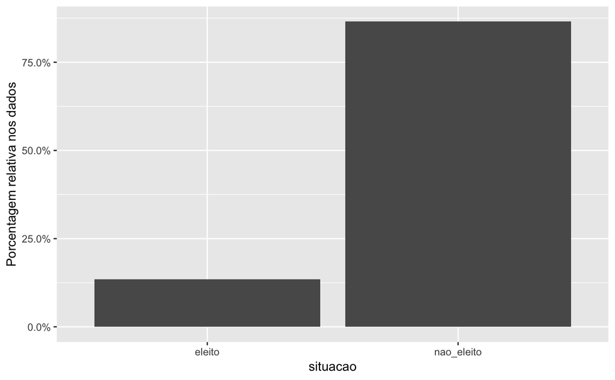

```r
train_data %>% ggplot(aes(situacao)) + geom_bar(aes(y = (..count..)/sum(..count..))) + scale_y_continuous(labels=scales::percent) + ylab("Porcentagem relativa nos dados")
```

Observamos que a situação não eleito está presente em mais de 80% dos dados de treinamento, nesse caso observamos uma desbalanceamento em uma grande proporção, considerando que eleito equivale a menos de 15% dos dados. Desse modo, pode ser criado um viés na qual o modelo aprenderá a ignorar as classes menos frequentes, levando a um impacto negativo na generalização do modelo e seu desempenho. O tratamento desses desbalanceamento pode ser dado de duas formas, são elas:

- Undersampling
- Oversampling

## Pre-processamento dos dados

Dividimos o conjunto de traino em traino e validação para poder validar o modelo.

```r
partition <- createDataPartition(y = train_data$situacao, p=0.75, list=FALSE)
set.seed(9560)
train <- train_data[partition, ]
validacao <- train_data[-partition, ]
```

Iremos “limpar os dados” desconsiderando algumas variaveis na qual não consideramos nescessaria para a geração dos modelos.

```r
set.seed(107)
train <- train %>%
          select(-partido,
                 -uf,-nome,
                 -estado_civil,
                 -ocupacao,-ano,
                 -cargo,-grau,-sexo,
                 -sequencial_candidato)
validacao <- validacao %>%
          select(-partido,
                 -uf,-nome,
                 -estado_civil,
                 -ocupacao,-ano,
                 -cargo,-grau,-sexo,
                 -sequencial_candidato)
test <- test_data %>%
          select(-partido,
                 -uf,-nome,
                 -estado_civil,
                 -ocupacao,-ano,
                 -cargo,-grau,-sexo)
```

Levando em consideração o desbalacemaneto existente, iremos utilizar a função SMOTE para o balancemaneto.

> A função SMOTE faz sobreamostragem de seu evento raro usando bootstrapping e k-neighbor mais próximo para criar sinteticamente observações adicionais daquele evento.

```r
set.seed(107)
train <- train %>% SMOTE(situacao ~ .,
                          data = .,
                          perc.over = 200,
                          perc.under=200)
validacao <- validacao %>% SMOTE(situacao ~ .,
                          data = .,
                          perc.over = 200,
                          perc.under=200)
train %>%
  group_by(situacao) %>%
  summarise(num = n()) %>%
  ungroup() %>%
  mutate(total = sum(num))
```

| situacao | num | total |
| --- | --- | --- |
| eleito | 2310 | 5390 |
| nao_eleito | 3080 | 5390 |

### Keras date

```r
train_d <- train
train <- as.matrix(train)
dimnames(train) <- NULL
```

## Model

```r
model <- keras_model_sequential()
model %>%
    layer_dense(units = 8, activation = 'relu', input_shape = c(14)) %>%
    layer_dense(units = 1, activation = 'softmax')
```

```r
model %>% compile(loss = 'categorical_crossentropy',
     optimizer = 'adam',
     metrics = 'accuracy')
```

```r
model %>% fit(
     x_train,
     y_train,
     epochs = 200,
     batch_size = 5,
     validation_split = 0.2
 )
```

[output not shown]